# Experiment 3 JP participants' beliefs about knowledge

```r
newcore=subset(newdata,newdata$Type=="core")
descr.all <-describeBy(newcore$When.estimate,list(newcore$Condition,newcore$Experiment),na.rm=TRUE,mat=TRUE)
descr.all$confIV1 = descr.all$mean-1.96*descr.all$se
descr.all$confIV2 = descr.all$mean+1.96*descr.all$se
descr.all
```

|  | item | group1 | group2 | vars | n | mean | sd | median | trimmed | mad | min | max | range | skew | kurtosis | se | confIV1 | confIV2 |
| --- | --- | --- | --- | --- | --- | --- | --- | --- | --- | --- | --- | --- | --- | --- | --- | --- | --- | --- |
| X11 | 1 | JP | 1 | 1 | 100 | 2.480960 | 1.7084374 | 2.032904 | 2.171766 | 1.0928233 | 0.6751980 | 11.842169 | 11.166971 | 2.6496597 | 9.5990667 | 0.17084374 | 2.146106 | 2.815814 |
| X12 | 2 | US | 1 | 1 | 101 | 2.225310 | 0.9936087 | 2.032904 | 2.136959 | 0.9850321 | 0.7230630 | 4.703842 | 3.980779 | 0.7118558 | -0.1991332 | 0.09886776 | 2.031530 | 2.419091 |
| X13 | 3 | JP | 4 | 1 | 102 | 2.728355 | 1.6450133 | 2.384051 | 2.523803 | 1.4121185 | 0.2835914 | 10.261301 | 9.977709 | 1.5459095 | 3.6669392 | 0.16288059 | 2.409109 | 3.047601 |
| X14 | 4 | US | 4 | 1 | 101 | 4.466968 | 3.3683699 | 3.605629 | 3.978262 | 2.7026209 | 0.4271866 | 16.074572 | 15.647386 | 1.4027642 | 1.8957700 | 0.33516533 | 3.810044 | 5.123892 |

```r
#When.estimate
```

```r
descr.all <-describeBy(newcore$How,list(newcore$Condition,newcore$Experiment),na.rm=TRUE,mat=TRUE)
descr.all$confIV1 = descr.all$mean-1.96*descr.all$se
descr.all$confIV2 = descr.all$mean+1.96*descr.all$se
descr.all
```

|  | item | group1 | group2 | vars | n | mean | sd | median | trimmed | mad | min | max | range | skew | kurtosis | se | confIV1 | confIV2 |
| --- | --- | --- | --- | --- | --- | --- | --- | --- | --- | --- | --- | --- | --- | --- | --- | --- | --- | --- |
| X11 | 1 | JP | 1 | 1 | 99 | 0.6605099 | 0.2719872 | 0.6666667 | 0.6774250 | 0.39536 | 0 | 1 | 1 | -0.3392329 | -0.7195317 | 0.02733574 | 0.6069318 | 0.7140879 |
| X12 | 2 | US | 1 | 1 | 100 | 0.7700000 | 0.2286396 | 0.8333333 | 0.7997024 | 0.24710 | 0 | 1 | 1 | -1.0718876 | 0.9406992 | 0.02286396 | 0.7251866 | 0.8148134 |
| X13 | 3 | JP | 4 | 1 | 102 | 0.7254902 | 0.2306888 | 0.7142857 | 0.7543554 | 0.21180 | 0 | 1 | 1 | -1.0617182 | 1.1888861 | 0.02284160 | 0.6807207 | 0.7702597 |
| X14 | 4 | US | 4 | 1 | 101 | 0.6152758 | 0.3318117 | 0.7142857 | 0.6366843 | 0.42360 | 0 | 1 | 1 | -0.2944683 | -1.3001780 | 0.03301650 | 0.5505635 | 0.6799882 |

```r
#How
```

```r
descr.all <-describeBy(as.numeric(summ.output$Education),list(summ.output$Condition),na.rm=TRUE,mat=TRUE)
descr.all$confIV1 = descr.all$mean-1.96*descr.all$se
descr.all$confIV2 = descr.all$mean+1.96*descr.all$se
descr.all
```

|  | item | group1 | vars | n | mean | sd | median | trimmed | mad | min | max | range | skew | kurtosis | se | confIV1 | confIV2 |
| --- | --- | --- | --- | --- | --- | --- | --- | --- | --- | --- | --- | --- | --- | --- | --- | --- | --- |
| X11 | 1 | JP | 1 | 408 | 1.549020 | 0.5542323 | 2 | 1.524390 | 1.4826 | 1 | 3 | 2 | 0.32488705 | -0.9408735 | 0.02743859 | 1.495240 | 1.602799 |
| X12 | 2 | US | 1 | 404 | 2.168317 | 0.7054458 | 2 | 2.197531 | 0.0000 | 1 | 4 | 3 | -0.07894269 | -0.6700350 | 0.03509724 | 2.099526 | 2.237107 |

```r
output.core=subset(summ.output,summ.output$Type=="core")
t.test(output.core$How,mu=0.5)
```

```
    One Sample t-test

data:  output.core$How
t = 8.3811, df = 202, p-value = 8.849e-15
alternative hypothesis: true mean is not equal to 0.5
95 percent confidence interval:
 0.6305054 0.7108035
sample estimates:
mean of x
0.6706545
```

```r
t.test(How~Condition,data=output.core)
```

```
    Welch Two Sample t-test

data:  How by Condition
t = 2.7452, df = 178.21, p-value = 0.006667
alternative hypothesis: true difference in means is not equal to 0
95 percent confidence interval:
 0.03098857 0.18944019
sample estimates:
mean in group JP mean in group US
       0.7254902        0.6152758
```

```r
output.sensory = subset(summ.output,summ.output$Type=="sensory")
t.test(How~Condition,data=output.sensory)
```

```
    Welch Two Sample t-test

data:  How by Condition
t = -2.1959, df = 194.78, p-value = 0.02928
alternative hypothesis: true difference in means is not equal to 0
95 percent confidence interval:
 -0.171073796 -0.009182465
sample estimates:
mean in group JP mean in group US
       0.1029412        0.1930693
```

```r
output.read = subset(summ.output,summ.output$Type=="read")
t.test(How~Condition,data=output.read)
```

```
    Welch Two Sample t-test

data:  How by Condition
t = 2.0016, df = 190.7, p-value = 0.04675
alternative hypothesis: true difference in means is not equal to 0
95 percent confidence interval:
 0.00160423 0.21893547
sample estimates:
mean in group JP mean in group US
       0.8627451        0.7524752
```

```r
t.test(When.estimate~Condition,data=output.core)
```

```
    Welch Two Sample t-test

data:  When.estimate by Condition
t = -4.6656, df = 144.81, p-value = 6.939e-06
alternative hypothesis: true difference in means is not equal to 0
95 percent confidence interval:
 -2.475143 -1.002083
sample estimates:
mean in group JP mean in group US
        2.728355         4.466968
```

```r
t.test(When.estimate~Condition,data=output.sensory)
```

```
    Welch Two Sample t-test

data:  When.estimate by Condition
t = -5.1418, df = 107.87, p-value = 1.224e-06
alternative hypothesis: true difference in means is not equal to 0
95 percent confidence interval:
 -2.599195 -1.152781
sample estimates:
mean in group JP mean in group US
       0.5323838        2.4083722
```

```r
t.test(When.estimate~Condition,data=output.read)
```

```
    Welch Two Sample t-test

data:  When.estimate by Condition
t = -2.2262, df = 187.55, p-value = 0.02719
alternative hypothesis: true difference in means is not equal to 0
95 percent confidence interval:
 -2.4489834 -0.1478771
sample estimates:
mean in group JP mean in group US
        4.220048         5.518478
```

```r
t.test(as.numeric(summ.output$Education)~summ.output$Condition)
```

```
    Welch Two Sample t-test

data:  as.numeric(summ.output$Education) by summ.output$Condition
t = -13.901, df = 763.69, p-value < 2.2e-16
alternative hypothesis: true difference in means is not equal to 0
95 percent confidence interval:
 -0.7067520 -0.5318424
sample estimates:
mean in group JP mean in group US
        1.549020         2.168317
```

```r
# Loading the library
library(glmnet)
output.r1=output.core[,-c(7:25,28,32:34,39)]
# Loading the data
#data(output.r1)
x_vars <- model.matrix(When.estimate~. , output.r1)[,-12]
y_var <- output.r1$When.estimate
lambda_seq <- 10^seq(2, -2, by = -.1)
# Splitting the data into test and train
set.seed(86)
train = sample(1:nrow(x_vars), nrow(x_vars)/2)
x_test = (-train)
y_test = y_var[x_test]
cv_output <- cv.glmnet(x_vars[train,], y_var[train],
                       alpha = 1, lambda = lambda_seq,
                       nfolds = 5)
# identifying best lamda
best_lam <- cv_output$lambda.min
best_lam
```

```
[1] 0.1584893
```

```r
# Rebuilding the model with best lamda value identified
lasso_best <- glmnet(x_vars[train,], y_var[train], alpha = 1, lambda = best_lam)
pred <- predict(lasso_best, s = best_lam, newx = x_vars[x_test,])
coef(lasso_best)
```

```
18 x 1 sparse Matrix of class "dgCMatrix"
                                             s0
(Intercept)                          1.71676161
(Intercept)                          .
SubID                                .
Education                            0.13098916
Age                                 -0.02339125
GenderMale                           .
ConditionUS                          .
Experiment                           .
freewill                             0.32872311
afterlife                            .
parentYes                            0.61957976
religion                             .
religion.cateChristianity            1.78729674
religion.cateHinduism                .
religion.cateI prefer not to answer  .
religion.cateIslam                   .
religion.cateJudaism                 .
religion.catenon-religious           .
```

```r
fit.lm <- glm(When.estimate~Condition+parent+evolution+crystal+fluid+Christianity,family=gaussian,data=output.core)
summary(fit.lm)
```

```
Call:
glm(formula = When.estimate ~ Condition + parent + evolution +
    crystal + fluid + Christianity, family = gaussian, data = output.core)

Deviance Residuals:
    Min       1Q   Median       3Q      Max
-4.9178  -1.3971  -0.2875   0.7177  12.0796

Coefficients:
                 Estimate Std. Error t value Pr(>|t|)
(Intercept)       1.82516    0.63264   2.885  0.00435 **
ConditionUS       0.24956    0.52872   0.472  0.63745
parentYes         0.22696    0.37409   0.607  0.54475
evolutionTRUE    -0.97774    0.39758  -2.459  0.01480 *
crystal           0.32319    0.13305   2.429  0.01605 *
fluid             0.05072    0.12204   0.416  0.67817
ChristianityTRUE  1.16135    0.53339   2.177  0.03066 *
---
Signif. codes:  0 ‘***’ 0.001 ‘**’ 0.01 ‘*’ 0.05 ‘.’ 0.1 ‘ ’ 1

(Dispersion parameter for gaussian family taken to be 6.259083)

    Null deviance: 1561.3  on 201  degrees of freedom
Residual deviance: 1220.5  on 195  degrees of freedom
  (1 observation deleted due to missingness)
AIC: 952.6

Number of Fisher Scoring iterations: 2
```

```r
lm.beta(fit.lm)
```

```
Call:
glm(formula = When.estimate ~ Condition + parent + evolution +
    crystal + fluid + Christianity, family = gaussian, data = output.core)

Standardized Coefficients::
     (Intercept)      ConditionUS        parentYes    evolutionTRUE          crystal
      0.00000000       0.04488215       0.04030270      -0.17414521       0.18288913
           fluid ChristianityTRUE
      0.03183031       0.20126356
```

```r
fit.lm <- glm(How~Condition+parent+evolution+crystal+fluid+Christianity,family=gaussian,data=output.core)
summary(fit.lm)
```

```
Call:
glm(formula = How ~ Condition + parent + evolution + crystal +
    fluid + Christianity, family = gaussian, data = output.core)

Deviance Residuals:
     Min        1Q    Median        3Q       Max
-0.71528  -0.18161   0.01089   0.22052   0.50210

Coefficients:
                  Estimate Std. Error t value Pr(>|t|)
(Intercept)       0.908405   0.070704  12.848   <2e-16 ***
ConditionUS      -0.041720   0.059090  -0.706   0.4810
parentYes        -0.084718   0.041807  -2.026   0.0441 *
evolutionTRUE    -0.023800   0.044434  -0.536   0.5928
crystal          -0.027529   0.014870  -1.851   0.0656 .
fluid            -0.006336   0.013639  -0.465   0.6428
ChristianityTRUE -0.053344   0.059612  -0.895   0.3720
---
Signif. codes:  0 ‘***’ 0.001 ‘**’ 0.01 ‘*’ 0.05 ‘.’ 0.1 ‘ ’ 1

(Dispersion parameter for gaussian family taken to be 0.07817652)

    Null deviance: 16.942  on 201  degrees of freedom
Residual deviance: 15.244  on 195  degrees of freedom
  (1 observation deleted due to missingness)
AIC: 67.272

Number of Fisher Scoring iterations: 2
```

```r
lm.beta(fit.lm)
```

```
Call:
glm(formula = How ~ Condition + parent + evolution + crystal +
    fluid + Christianity, family = gaussian, data = output.core)

Standardized Coefficients::
     (Intercept)      ConditionUS        parentYes    evolutionTRUE          crystal
      0.00000000      -0.07202737      -0.14441504      -0.04069399      -0.14954905
           fluid ChristianityTRUE
     -0.03817021      -0.08874417
```

```r
final <- cbind(y_var[x_test], pred)
```

```
number of rows of result is not a multiple of vector length (arg 1)
```

```r
# Checking the first six obs
head(final)
```

```
                    1
15 1.3685094 1.849840
23 1.2162281 1.058381
35 4.2069434 5.537090
39 4.4618176 5.112461
43 0.8274793 2.481884
51 1.5962906 2.438313
```

```r
######### linear regression ###########
output.core$crystal = as.numeric(output.core$crystal.nochange)+5-as.numeric(output.core$crystal.change)
```

```
NAs introduced by coercion
```

```r
output.core$fluid = as.numeric(output.core$fluid.nochange)+5-as.numeric(output.core$fluid.change)
output.core$evolution=(output.core$X.creationism=="Naturalistic Evolution")
output.core$Christianity = (output.core$religion.cate=="Christianity")
output.core$karma = output.core$bad.karma+output.core$good.karma
fit.lm <- lm(When.estimate~Condition+religion+Christianity+evolution,data=output.core)
summary(fit.lm)
```

```
Call:
lm(formula = When.estimate ~ Condition + religion + Christianity +
    evolution, data = output.core)

Residuals:
    Min      1Q  Median      3Q     Max
-4.6166 -1.4134 -0.5079  0.9211 11.7511

Coefficients:
                 Estimate Std. Error t value Pr(>|t|)
(Intercept)        2.0163     0.6280   3.211  0.00154 **
ConditionUS        0.3746     0.4970   0.754  0.45187
religion           0.3865     0.1450   2.666  0.00830 **
ChristianityTRUE   1.7979     0.5447   3.300  0.00115 **
evolutionTRUE     -1.2640     0.3914  -3.230  0.00145 **
---
Signif. codes:  0 ‘***’ 0.001 ‘**’ 0.01 ‘*’ 0.05 ‘.’ 0.1 ‘ ’ 1

Residual standard error: 2.501 on 198 degrees of freedom
Multiple R-squared:  0.2066,    Adjusted R-squared:  0.1906
F-statistic: 12.89 on 4 and 198 DF,  p-value: 2.402e-09
```

```r
lm.beta(fit.lm)
```

```
Call:
lm(formula = When.estimate ~ Condition + religion + Christianity +
    evolution, data = output.core)

Standardized Coefficients::
     (Intercept)      ConditionUS         religion ChristianityTRUE    evolutionTRUE
      0.00000000       0.06754254       0.18718104       0.31201668      -0.22587068
```

```r
fit.lm <- glm(When.estimate~Condition+religion+evolution,family=gaussian,data=output.core)
summary(fit.lm)
```

```
Call:
glm(formula = When.estimate ~ Condition + religion + evolution,
    family = gaussian, data = output.core)

Deviance Residuals:
    Min       1Q   Median       3Q      Max
-4.1801  -1.4951  -0.4459   0.9789  10.7259

Coefficients:
              Estimate Std. Error t value Pr(>|t|)
(Intercept)     2.7197     0.6052   4.494 1.19e-05 ***
ConditionUS     1.3934     0.3991   3.492 0.000591 ***
religion        0.2471     0.1421   1.739 0.083517 .
evolutionTRUE  -1.4765     0.3955  -3.733 0.000247 ***
---
Signif. codes:  0 ‘***’ 0.001 ‘**’ 0.01 ‘*’ 0.05 ‘.’ 0.1 ‘ ’ 1

(Dispersion parameter for gaussian family taken to be 6.567162)

    Null deviance: 1561.3  on 202  degrees of freedom
Residual deviance: 1306.9  on 199  degrees of freedom
AIC: 964.11

Number of Fisher Scoring iterations: 2
```

```r
lm.beta(fit.lm)
```

```
Call:
glm(formula = When.estimate ~ Condition + religion + evolution,
    family = gaussian, data = output.core)

Standardized Coefficients::
  (Intercept)   ConditionUS      religion evolutionTRUE
    0.0000000     0.2512217     0.1196763    -0.2638283
```

```r
output.core.temp=output.core
#output.core.temp$evolution=as.factor(output.core.temp$evolution=="old")
output.core.temp$religion.cate=as.factor(output.core.temp$religion.cate=="Christianity")
output.core.temp$intelligence = output.core.temp$crystal+output.core.temp$fluid
output.core.temp$karma = output.core.temp$bad.karma+output.core.temp$good.karma
  require(plyr)
output.core.temp$evo.score <- mapvalues(output.core.temp$evolution,
          from=c("old","new","intelligent design","evolution"),
          to=c(1,2,3,4))
output.core.temp$evo.score=as.numeric(output.core.temp$evo.score)
t.test(evo.score~Condition,data=output.core.temp)
```

```
    Welch Two Sample t-test

data:  evo.score by Condition
t = 5.7106, df = 198.67, p-value = 4.06e-08
alternative hypothesis: true difference in means is not equal to 0
95 percent confidence interval:
 0.2423119 0.4979327
sample estimates:
mean in group JP mean in group US
       0.6176471        0.2475248
```

```r
library(bayestestR)
#output.core.temp$Education=(as.numeric(output.core.temp$Education)>1)
output.core.temp$Education=as.numeric(output.core.temp$Education)
output.temp=summ.output
output.temp$Education=as.numeric(output.temp$Education)
fit1<-glm(When.estimate~Type+Condition+Education,family=gaussian,data=summ.output)
summary(fit1)
```

```
Call:
glm(formula = When.estimate ~ Type + Condition + Education, family = gaussian,
    data = summ.output)

Deviance Residuals:
    Min       1Q   Median       3Q      Max
-5.7608  -1.8616  -0.6524   0.8768  26.1323

Coefficients:
            Estimate Std. Error t value Pr(>|t|)
(Intercept)   3.1668     0.4089   7.745 2.86e-14 ***
Typecore     -1.6770     0.3491  -4.804 1.85e-06 ***
Typeread     -0.4043     0.3491  -1.158    0.247
Typesensory  -3.8046     0.3491 -10.899  < 2e-16 ***
ConditionUS   1.1151     0.2748   4.058 5.43e-05 ***
Education     0.8339     0.1949   4.278 2.11e-05 ***
---
Signif. codes:  0 ‘***’ 0.001 ‘**’ 0.01 ‘*’ 0.05 ‘.’ 0.1 ‘ ’ 1

(Dispersion parameter for gaussian family taken to be 12.36874)

    Null deviance: 12520.3  on 811  degrees of freedom
Residual deviance:  9969.2  on 806  degrees of freedom
AIC: 4354.7

Number of Fisher Scoring iterations: 2
```

```r
fit1<-glm(When.estimate~Condition+evolution+crystal+fluid,family=gaussian,data=output.core.temp)
summary(fit1)
```

```
Call:
glm(formula = When.estimate ~ Condition + evolution + crystal +
    fluid, family = gaussian, data = output.core.temp)

Deviance Residuals:
    Min       1Q   Median       3Q      Max
-4.6610  -1.4595  -0.3356   0.7318  11.1564

Coefficients:
              Estimate Std. Error t value Pr(>|t|)
(Intercept)    1.97558    0.62289   3.172  0.00176 **
ConditionUS    1.00927    0.41097   2.456  0.01492 *
evolutionTRUE -1.14752    0.39407  -2.912  0.00401 **
crystal        0.38627    0.13064   2.957  0.00349 **
fluid          0.01401    0.12207   0.115  0.90875
---
Signif. codes:  0 ‘***’ 0.001 ‘**’ 0.01 ‘*’ 0.05 ‘.’ 0.1 ‘ ’ 1

(Dispersion parameter for gaussian family taken to be 6.369577)

    Null deviance: 1561.3  on 201  degrees of freedom
Residual deviance: 1254.8  on 197  degrees of freedom
  (1 observation deleted due to missingness)
AIC: 954.2

Number of Fisher Scoring iterations: 2
```

```r
fit1<-glm(When.estimate~Condition+evolution+religion,family=gaussian,data=output.core)
fit2<-glm(When.estimate~Condition+religion,family=gaussian,data=output.core)
bf_models(fit1,fit2)
```

```
Bayes Factors for Model Comparison

       Model                   BF
[fit2] Condition + religion 0.015

* Against Denominator: [fit1] Condition + evolution + religion
*   Bayes Factor Type: BIC approximation
```

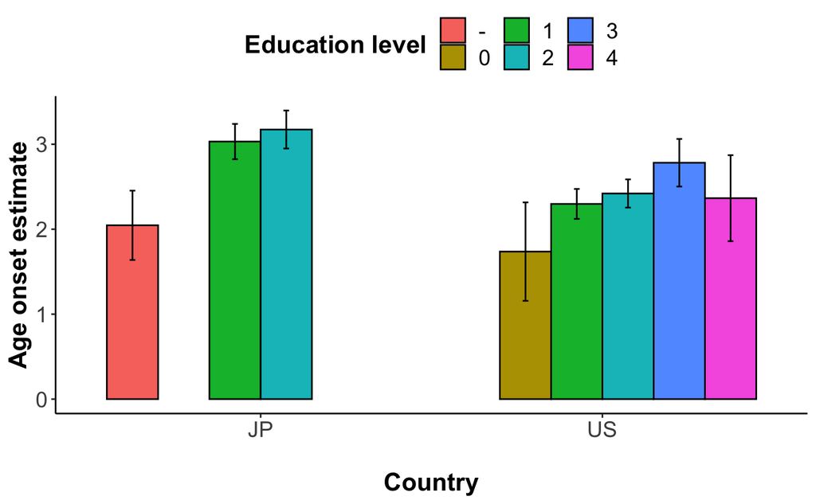

```r
all_descrep=describeBy(summ.output$When.estimate,group = list(summ.output$Condition,summ.output$Education), mat=TRUE)
all_descrep$lwr=all_descrep$mean-all_descrep$se
all_descrep$upr=all_descrep$mean+all_descrep$se
#all_descrep$group2=as.numeric(all_descrep$group2)
ggplot(data=all_descrep,aes(x=group1,y=mean,fill=group2))+
  geom_bar(stat="identity",color="black",position=position_dodge())+
  geom_errorbar(aes(ymin=lwr,ymax=upr),width=.1,
                position=position_dodge(.9))+
  #scale_y_continuous(labels = scales::percent, limits=c(0,1))+
  #scale_x_discrete()+
  labs(y="Age onset estimate", x="\nCountry",fill="Education level")+
  #geom_hline(yintercept=0.5,linetype="dashed",color="lightgray")+
  theme_classic()+
  theme(legend.position="top",
        legend.text=element_text(size=14),
        legend.title=element_text(size=16, face="bold"),
        axis.text=element_text(size=14),
        axis.title=element_text(size=16,face="bold"))
```

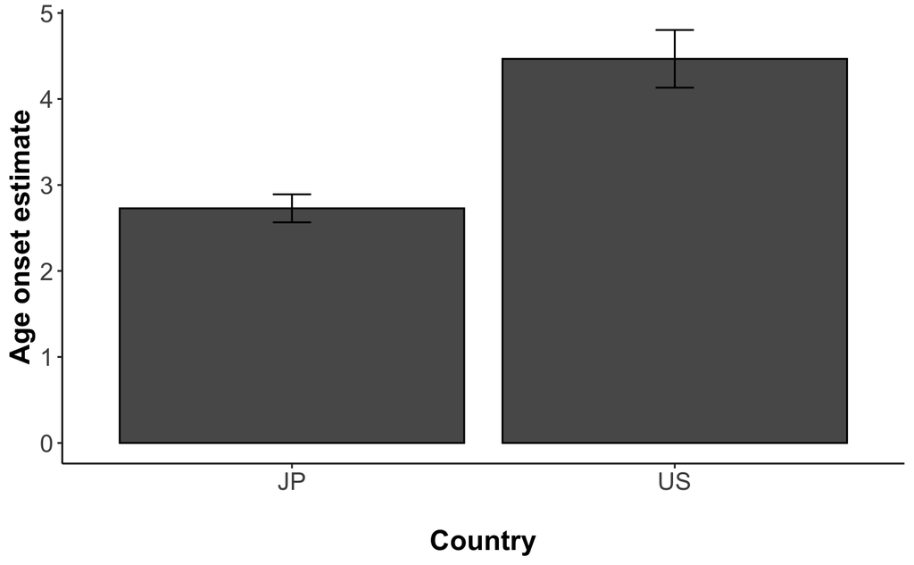

```r
all_descrep=describeBy(output.core.temp$When.estimate,group = list(output.core.temp$Condition), mat=TRUE)
all_descrep$lwr=all_descrep$mean-all_descrep$se
all_descrep$upr=all_descrep$mean+all_descrep$se
#all_descrep$group2=as.numeric(all_descrep$group2)
ggplot(data=all_descrep,aes(x=group1,y=mean))+
  geom_bar(stat="identity",color="black",position=position_dodge())+
  geom_errorbar(aes(ymin=lwr,ymax=upr),width=.1,
                position=position_dodge(.9))+
  #scale_y_continuous(labels = scales::percent, limits=c(0,1))+
  #scale_x_discrete()+
  labs(y="Age onset estimate", x="\nCountry")+
  #geom_hline(yintercept=0.5,linetype="dashed",color="lightgray")+
  theme_classic()+
  theme(legend.position="top",
        legend.text=element_text(size=14),
        legend.title=element_text(size=16, face="bold"),
        axis.text=element_text(size=14),
        axis.title=element_text(size=16,face="bold"))
```

```r
all_descrep=describeBy(output.core.temp$evo.score,group = list(output.core.temp$Condition), mat=TRUE)
```

```
no non-missing arguments to min; returning Infno non-missing arguments to max; returning -Infno non-missing arguments to min; returning Infno non-missing arguments to max; returning -Inf
```

[figure not shown]

```r
all_descrep$lwr=all_descrep$mean-all_descrep$se
all_descrep$upr=all_descrep$mean+all_descrep$se
#all_descrep$group2=as.numeric(all_descrep$group2)
ggplot(data=all_descrep,aes(x=group1,y=mean))+
  geom_bar(stat="identity",color="black",position=position_dodge())+
  geom_errorbar(aes(ymin=lwr,ymax=upr),width=.1,
                position=position_dodge(.9))+
  #scale_y_continuous(labels = scales::percent, limits=c(0,1))+
  #scale_x_discrete()+
  labs(y="Evolution/Creation beliefs", x="\nCountry")+
  #geom_hline(yintercept=0.5,linetype="dashed",color="lightgray")+
  theme_classic()+
  theme(legend.position="top",
        legend.text=element_text(size=14),
        legend.title=element_text(size=16, face="bold"),
        axis.text=element_text(size=14),
        axis.title=element_text(size=16,face="bold"))
```

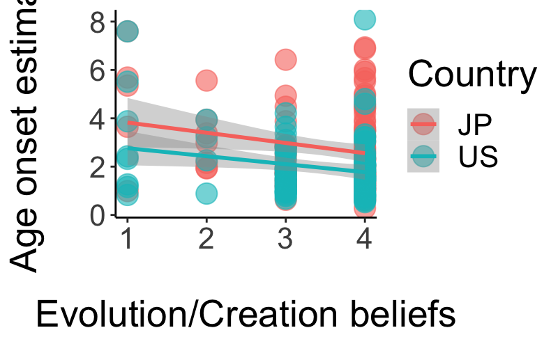

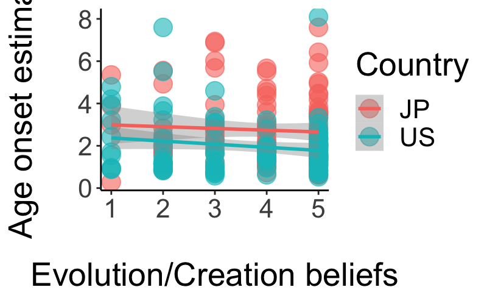

[output not shown]

[figure not shown]

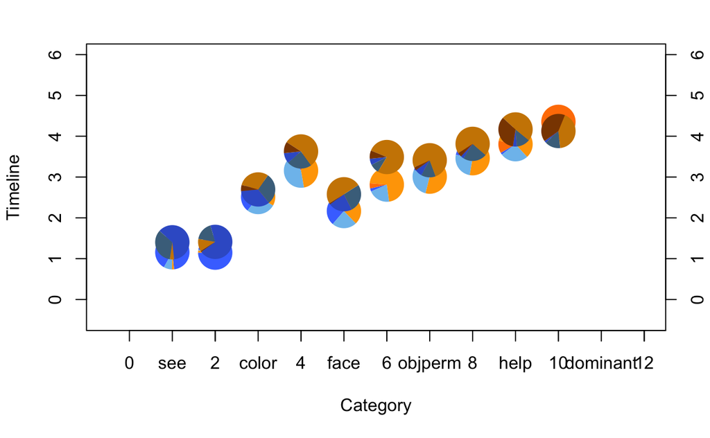